# Assignment3_yimin wang_yw3454

# (a) A summary of takeaways

### My first takeaway is the 15 technical indicators in the Appendix, where the authors summarized formulas to calculate these indicators and concrete interpretation of how to use these indicators in technical analysis. My second takeaway is the novel algorithmic trading model that this article uses to develop transaction strategies. It is innovative to convert 1-D financial time series into a 2-D image-like data to utilizing CNN for the trading system. Last but not least, I’m impressed by the comparison of annualized returns with the BaH strategy and the other 4 strategies. It is worth noting that the algorithm beat BaH consistently and noticeably.

# (b) Exploratory Data Analysis

### Get Data

```r
library(dplyr) # or just dplyr
library(quantmod)
library(TTR)
library(PerformanceAnalytics)
```

```r
library("IRdisplay")
library(ggplot2)
```

### The first stock I choose is Netflix: NFLX

```r
getSymbols(c("NFLX"))
```

[output not shown]

```
## [1] "NFLX"
```

```r
tail(NFLX)
```

```
##            NFLX.Open NFLX.High NFLX.Low NFLX.Close NFLX.Volume NFLX.Adjusted
## 2020-09-18    472.51    479.40   458.60     469.96     6717700        469.96
## 2020-09-21    467.69    487.78   466.32     487.35     5457500        487.35
## 2020-09-22    489.01    491.82   479.26     491.17     3482300        491.17
## 2020-09-23    491.04    491.04   469.00     470.61     3726400        470.61
## 2020-09-24    470.53    477.00   467.82     473.08     3727200        473.08
## 2020-09-25    474.39    484.87   468.03     482.88     3767700        482.88
```

```r
df_N <- NFLX
head(df_N)
```

```
##            NFLX.Open NFLX.High NFLX.Low NFLX.Close NFLX.Volume NFLX.Adjusted
## 2007-01-03  3.714286  3.824286 3.677143   3.801429    16440900      3.801429
## 2007-01-04  3.772857  3.828571 3.585714   3.621428    15959300      3.621428
## 2007-01-05  3.620000  3.620000 3.492857   3.544286    15190700      3.544286
## 2007-01-08  3.545714  3.555714 3.367143   3.404286    18344900      3.404286
## 2007-01-09  3.427143  3.440000 3.360000   3.427143    10611300      3.427143
## 2007-01-10  3.424286  3.464286 3.411429   3.438571    11448500      3.438571
```

### The second stock is Macy’s: M

```r
getSymbols(c("M"))
```

```
## [1] "M"
```

```r
tail(M)
```

```
##            M.Open M.High M.Low M.Close M.Volume M.Adjusted
## 2020-09-18   6.87   6.92  6.73    6.76 22678300       6.76
## 2020-09-21   6.57   6.60  6.24    6.31 25119500       6.31
## 2020-09-22   6.38   6.39  6.14    6.27 21823900       6.27
## 2020-09-23   6.33   6.48  6.11    6.11 18078300       6.11
## 2020-09-24   6.11   6.21  5.89    6.03 20520100       6.03
## 2020-09-25   6.03   6.12  5.95    6.03 17336800       6.03
```

```r
df_M <- M
head(df_M)
```

```
##            M.Open M.High M.Low M.Close M.Volume M.Adjusted
## 2007-01-03  38.20  38.72 37.09   37.51 10278900   24.19612
## 2007-01-04  37.60  38.30 37.30   37.31 10699000   24.06712
## 2007-01-05  37.35  37.42 36.72   36.89 10002000   23.79620
## 2007-01-08  37.07  37.75 36.12   37.60 10049900   24.25418
## 2007-01-09  37.60  38.91 37.60   38.85  8865300   25.06050
## 2007-01-10  38.70  38.97 38.20   38.82  4737800   25.04115
```

### The third stock is 3M: MMM

```r
getSymbols(c("MMM"))
```

```
## [1] "MMM"
```

```r
tail(MMM)
```

```
##            MMM.Open MMM.High MMM.Low MMM.Close MMM.Volume MMM.Adjusted
## 2020-09-18   172.06   172.78  169.47    169.55    4084500       169.55
## 2020-09-21   165.98   166.67  159.64    161.36    3911700       161.36
## 2020-09-22   161.06   163.67  160.42    162.34    2103800       162.34
## 2020-09-23   162.52   164.24  159.12    159.51    2248200       159.51
## 2020-09-24   159.40   161.96  158.07    160.42    1569700       160.42
## 2020-09-25   159.31   160.98  158.86    160.27    1948900       160.27
```

```r
df_3M <- MMM
head(df_3M)
```

```
##            MMM.Open MMM.High MMM.Low MMM.Close MMM.Volume MMM.Adjusted
## 2007-01-03    77.53    78.85   77.38     78.26    3781500     54.00246
## 2007-01-04    78.40    78.41   77.45     77.95    2968400     53.78855
## 2007-01-05    77.89    77.90   77.01     77.42    2765200     53.42280
## 2007-01-08    77.42    78.04   76.97     77.59    2434500     53.54012
## 2007-01-09    78.00    78.23   77.44     77.68    1896800     53.60223
## 2007-01-10    77.31    77.96   77.04     77.85    1787500     53.71953
```

### Stock returns: Take Netflix as an example, I visualized the distribution of returns by day, week, and month. We can see higher standard deviation and lower kurtosis as return periods become longer. This is in line with intuitive because stock returns are more volatile from month to month than from day to day.

```r
rtn.daily <- dailyReturn(df_N) # returns by day
rtn.weekly <- weeklyReturn(df_N) # returns by week
rtn.monthly <- monthlyReturn(df_N) # returns by month, indexed by yearmon
# daily,weekly,monthly,quarterly, and yearly
rtn.allperiods <- allReturns(df_N) # note the plural
head(rtn.daily)
```

```
##            daily.returns
## 2007-01-03   0.023461575
## 2007-01-04  -0.047350878
## 2007-01-05  -0.021301542
## 2007-01-08  -0.039500198
## 2007-01-09   0.006714183
## 2007-01-10   0.003334556
```

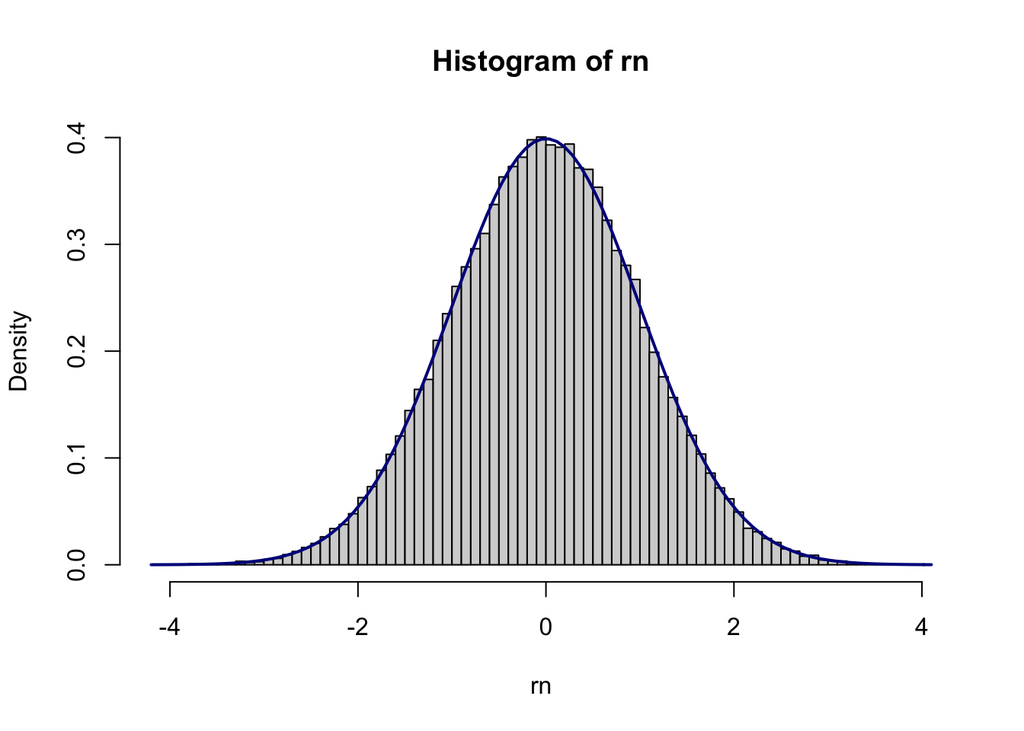

```r
# Generate a standard normal distribution
rn <- rnorm(100000)
options(repr.plot.width = 4, repr.plot.height = 4)
hist(rn,breaks=100,prob=TRUE)
curve(dnorm(x, mean=0, sd=1), col="darkblue", lwd=2, add=TRUE ) # Overlay a standard normal distribution
```

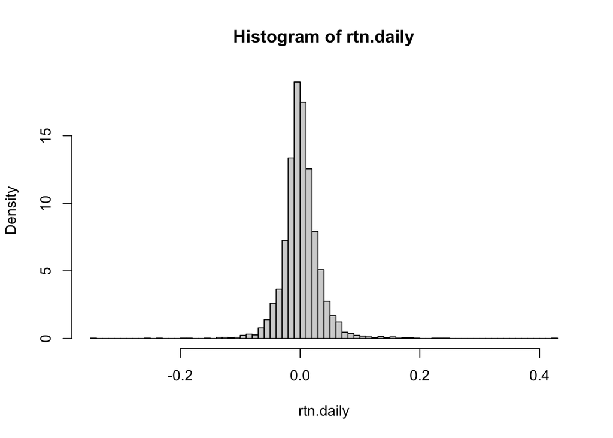

```r
# Daily return
# Histogram of daily return
options(repr.plot.width = 4, repr.plot.height = 4)
hist(rtn.daily, breaks=100, prob=TRUE)
```

```r
print(paste0("standard deviation: ", sd(rtn.daily)))
```

```
## [1] "standard deviation: 0.0329467762366449"
```

```r
print(paste0("Kurtosis: ", round(kurtosis(rtn.daily),2)))
```

```
## [1] "Kurtosis: 18.51"
```

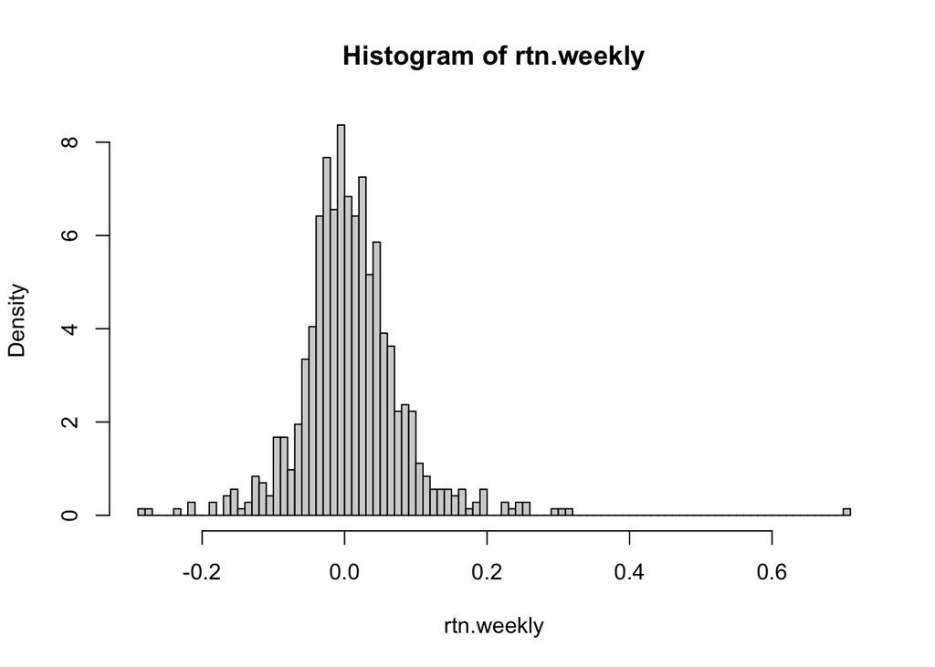

```r
# Weekly return
# Histogram of weekly return
options(repr.plot.width = 4, repr.plot.height = 5)
hist(rtn.weekly, breaks=100, prob=TRUE)
```

```r
print(paste0("standard deviation: ", sd(rtn.weekly)))
```

```
## [1] "standard deviation: 0.0748652003349612"
```

```r
print(paste0("Kurtosis: ", round(kurtosis(rtn.weekly),2)))
```

```
## [1] "Kurtosis: 12.28"
```

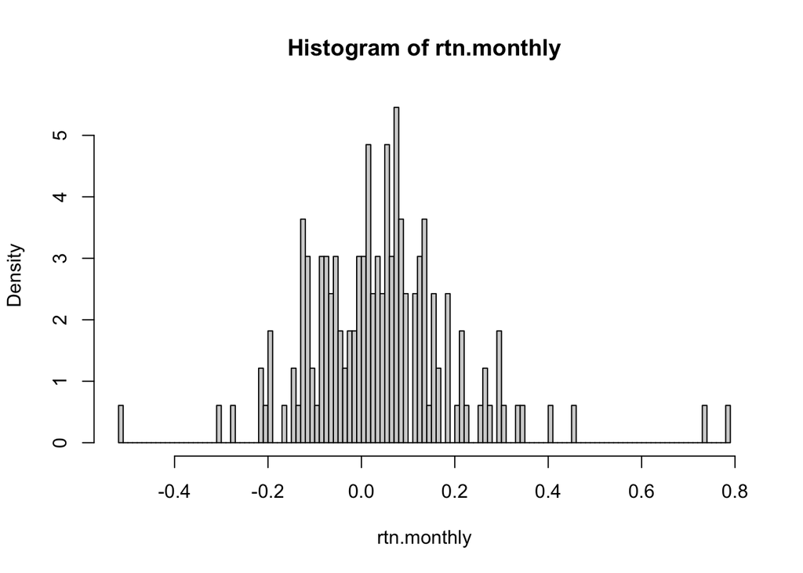

```r
# Monthly return
# Histogram of monthly return
options(repr.plot.width = 4, repr.plot.height = 5)
hist(rtn.monthly, breaks=100, prob=TRUE)
```

```r
print(paste0("standard deviation: ", sd(rtn.monthly)))
```

```
## [1] "standard deviation: 0.159331767609861"
```

```r
print(paste0("Kurtosis: ", round(kurtosis(rtn.monthly),2)))
```

```
## [1] "Kurtosis: 4.58"
```

### Netflix Trading Strategies

```r
# Netflix
macd <- MACD(NFLX$NFLX.Adjusted, nFast = 12, nSlow = 26, nSig = 9, maType = "SMA", percent = FALSE)
rsi <- RSI(NFLX$NFLX.Adjusted, n = 14, maType = "SMA")

# Strategy 1: if macd>signal, enter and stay in the market. If macd<signal, exit the market.
strategy1 <- ifelse ((macd$signal < macd$macd) , 1, 0)
strategy1[is.na(strategy1)] <-0

# Strategy 2: if oversold, enter and stay in the market.
strategy2 <- ifelse ((macd$signal > macd$macd) & (rsi$rsi < 30), 1, 0)
strategy2[is.na(strategy2)] <-0

# Buy-and-hold: keep it all time. So "1", not "0"
bh_strategy <- rep(1,dim(macd)[1])
```

### Backtesting

```r
# Netflix: Buy-and-hold strategy
BH_backtest <- function(df,from_date,to_date,strategy_name){
    rtn.daily <- dailyReturn(df) # returns by day
    trade_return <- rtn.daily[index(rtn.daily)<=to_date & index(rtn.daily)>=from_date]
    cumm_return <- Return.cumulative(trade_return)
    annual_return <- Return.annualized(trade_return)
    summary(as.ts(trade_return))
    SharpeRatio <- SharpeRatio(as.ts(trade_return), Rf = 0, p = 0.95, FUN = "StdDev")
    SharpeRatioAnnualized <- SharpeRatio.annualized(trade_return, Rf = 0)
    out <- as.data.frame(c(cumm_return,annual_return,SharpeRatio,SharpeRatioAnnualized))
    out <- round(out,2)
    colnames(out) <- strategy_name
    row.names(out) <- c('Cumulative Return','Annualized Return','Sharpe Ratio','Annualized Sharpe Ratio')

  return( out )
    }

buy_and_hold_performance <- BH_backtest(df_N, from_date = '2009-01-01', to_date = '2019-12-31',"Buy & Hold Strategy")
buy_and_hold_performance
```

```
##                         Buy & Hold Strategy
## Cumulative Return                     74.78
## Annualized Return                      0.48
## Sharpe Ratio                           0.06
## Annualized Sharpe Ratio                0.94
```

```r
backtest <- function(df,from_date,to_date,strategy,strategy_name){
    rtn.daily <- dailyReturn(df) # returns by day
    trade_return <- rtn.daily[index(rtn.daily)<=to_date & index(rtn.daily)>=from_date]*stats::lag(strategy, na.pad = FALSE)
    cumm_return <- Return.cumulative(trade_return)
    annual_return <- Return.annualized(trade_return)
    summary(as.ts(trade_return))
    SharpeRatio <- SharpeRatio(as.ts(trade_return), Rf = 0, p = 0.95, FUN = "StdDev")
    SharpeRatioAnnualized <- SharpeRatio.annualized(trade_return, Rf = 0)
    out <- as.data.frame(c(cumm_return,annual_return,SharpeRatio,SharpeRatioAnnualized))
    out <- round(out,2)
    colnames(out) <- strategy_name
    row.names(out) <- c('Cumulative Return','Annualized Return','Sharpe Ratio','Annualized Sharpe Ratio')

  return( out )
    }
```

```r
# Netflix: Strategy 1
strategy1_performance <- backtest(NFLX, from_date = '2009-01-01', to_date = '2019-12-31', strategy1,"Strategy1")
strategy1_performance
```

```
##                         Strategy1
## Cumulative Return            3.37
## Annualized Return            0.14
## Sharpe Ratio                 0.03
## Annualized Sharpe Ratio      0.38
```

```r
# Netflix: Strategy 2
strategy2_performance <- backtest(NFLX, from_date = '2009-01-01', to_date = '2019-12-31', strategy2,"Strategy2")
strategy2_performance
```

```
##                         Strategy2
## Cumulative Return            1.23
## Annualized Return            0.08
## Sharpe Ratio                 0.03
## Annualized Sharpe Ratio      0.48
```

### Macy’s Trading Strategies

```r
# Macy's
macd <- MACD(M$M.Adjusted, nFast = 12, nSlow = 26, nSig = 9, maType = "SMA", percent = FALSE)
rsi <- RSI(M$M.Adjusted, n = 14, maType = "SMA")

# Strategy 1: if macd>signal, enter and stay in the market. If macd<signal, exit the market.
strategy1 <- ifelse ((macd$signal < macd$macd) , 1, 0)
strategy1[is.na(strategy1)] <-0

# Strategy 2: if overbought, enter and stay in the market.
strategy2 <- ifelse ((macd$signal < macd$macd) & (rsi$rsi > 70), 1, 0)
strategy2[is.na(strategy2)] <-0

# Buy-and-hold: keep it all time. So "1", not "0"
bh_strategy <- rep(1,dim(macd)[1])
```

### Backtesting

```r
# Macy's: Buy-and-hold strategy
BH_backtest <- function(df,from_date,to_date,strategy_name){
    rtn.daily <- dailyReturn(df) # returns by day
    trade_return <- rtn.daily[index(rtn.daily)<=to_date & index(rtn.daily)>=from_date]
    cumm_return <- Return.cumulative(trade_return)
    annual_return <- Return.annualized(trade_return)
    summary(as.ts(trade_return))
    SharpeRatio <- SharpeRatio(as.ts(trade_return), Rf = 0, p = 0.95, FUN = "StdDev")
    SharpeRatioAnnualized <- SharpeRatio.annualized(trade_return, Rf = 0)
    out <- as.data.frame(c(cumm_return,annual_return,SharpeRatio,SharpeRatioAnnualized))
    out <- round(out,2)
    colnames(out) <- strategy_name
    row.names(out) <- c('Cumulative Return','Annualized Return','Sharpe Ratio','Annualized Sharpe Ratio')

  return( out )
    }

buy_and_hold_performance <- BH_backtest(M, from_date = '2009-01-01', to_date = '2019-12-31',"Buy & Hold Strategy")
buy_and_hold_performance
```

```
##                         Buy & Hold Strategy
## Cumulative Return                      0.64
## Annualized Return                      0.05
## Sharpe Ratio                           0.02
## Annualized Sharpe Ratio                0.12
```

```r
# Macy's: Strategy 1
strategy1_performance <- backtest(M, from_date = '2009-01-01', to_date = '2019-12-31', strategy1,"Strategy1")
strategy1_performance
```

```
##                         Strategy1
## Cumulative Return            0.95
## Annualized Return            0.06
## Sharpe Ratio                 0.02
## Annualized Sharpe Ratio      0.23
```

```r
# Macy's: Strategy 2
strategy2_performance <- backtest(M, from_date = '2009-01-01', to_date = '2019-12-31', strategy2,"Strategy2")
strategy2_performance
```

```
##                         Strategy2
## Cumulative Return            0.25
## Annualized Return            0.02
## Sharpe Ratio                 0.01
## Annualized Sharpe Ratio      0.16
```

### 3M Trading Strategies

```r
# 3M's
macd <- MACD(MMM$MMM.Adjusted, nFast = 12, nSlow = 26, nSig = 9, maType = "SMA", percent = FALSE)
rsi <- RSI(MMM$MMM.Adjusted, n = 14, maType = "SMA")

# Strategy 1: if macd>signal, enter and stay in the market. If macd<signal, exit the market.
strategy1 <- ifelse ((macd$signal < macd$macd) , 1, 0)
strategy1[is.na(strategy1)] <-0

# Strategy 2: if oversold, enter and stay in the market.
strategy2 <- ifelse ((macd$signal > macd$macd) & (rsi$rsi < 30), 1, 0)
strategy2[is.na(strategy2)] <-0

# Buy-and-hold: keep it all time. So "1", not "0"
bh_strategy <- rep(1,dim(macd)[1])
```

### Backtesting

```r
# 3M: Buy-and-hold strategy
BH_backtest <- function(df,from_date,to_date,strategy_name){
    rtn.daily <- dailyReturn(df) # returns by day
    trade_return <- rtn.daily[index(rtn.daily)<=to_date & index(rtn.daily)>=from_date]
    cumm_return <- Return.cumulative(trade_return)
    annual_return <- Return.annualized(trade_return)
    summary(as.ts(trade_return))
    SharpeRatio <- SharpeRatio(as.ts(trade_return), Rf = 0, p = 0.95, FUN = "StdDev")
    SharpeRatioAnnualized <- SharpeRatio.annualized(trade_return, Rf = 0)
    out <- as.data.frame(c(cumm_return,annual_return,SharpeRatio,SharpeRatioAnnualized))
    out <- round(out,2)
    colnames(out) <- strategy_name
    row.names(out) <- c('Cumulative Return','Annualized Return','Sharpe Ratio','Annualized Sharpe Ratio')

  return( out )
    }

buy_and_hold_performance <- BH_backtest(MMM, from_date = '2009-01-01', to_date = '2019-12-31',"Buy & Hold Strategy")
buy_and_hold_performance
```

```
##                         Buy & Hold Strategy
## Cumulative Return                      2.07
## Annualized Return                      0.11
## Sharpe Ratio                           0.04
## Annualized Sharpe Ratio                0.52
```

```r
# 3M: Strategy 1
strategy1_performance <- backtest(MMM, from_date = '2009-01-01', to_date = '2019-12-31', strategy1,"Strategy1")
strategy1_performance
```

```
##                         Strategy1
## Cumulative Return            0.93
## Annualized Return            0.06
## Sharpe Ratio                 0.03
## Annualized Sharpe Ratio      0.44
```

```r
# 3M: Strategy 2
strategy2_performance <- backtest(MMM, from_date = '2009-01-01', to_date = '2019-12-31', strategy2,"Strategy2")
strategy2_performance
```

```
##                         Strategy2
## Cumulative Return            0.01
## Annualized Return            0.00
## Sharpe Ratio                 0.00
## Annualized Sharpe Ratio      0.01
```

```r
buy_and_hold_performance_short_term <- BH_backtest(MMM, from_date = '2020-01-01', to_date = '2020-06-30',"Buy & Hold Strategy")
buy_and_hold_performance_short_term
```

```
##                         Buy & Hold Strategy
## Cumulative Return                     -0.12
## Annualized Return                     -0.22
## Sharpe Ratio                          -0.02
## Annualized Sharpe Ratio               -0.45
```

```r
strategy1_performance_short_term <- backtest(MMM, from_date = '2020-01-01', to_date = '2020-06-30', strategy1,"Strategy1")
strategy1_performance_short_term
```

```
##                         Strategy1
## Cumulative Return            0.11
## Annualized Return            0.24
## Sharpe Ratio                 0.06
## Annualized Sharpe Ratio      0.92
```

```r
strategy2_performance_short_term <- backtest(MMM, from_date = '2020-01-01', to_date = '2020-06-30', strategy2,"Strategy2")
strategy2_performance_short_term
```

```
##                         Strategy2
## Cumulative Return            0.07
## Annualized Return            0.15
## Sharpe Ratio                 0.07
## Annualized Sharpe Ratio      1.15
```

### Plot the technical charts

### First, I plotted the short-term performance of Netflix, Macy’s and 3M

### From the performance of the last 3 months, we can conclude that stock prices fluctuate from day to day. Continuous ups and downs create opportunities to make money from strategies on top of technical analysis.

# last 3 months

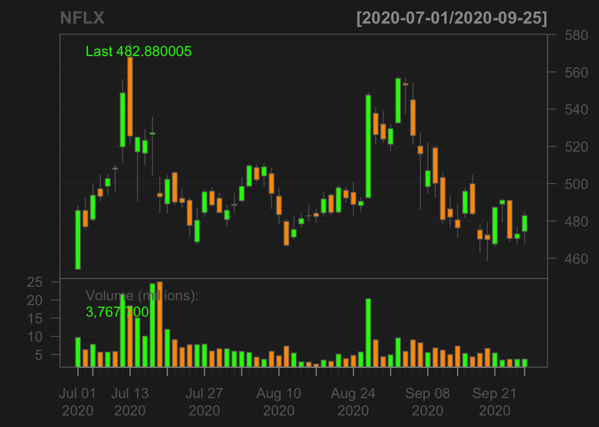

```r
# Netflix
options(repr.plot.width = 6, repr.plot.height = 3)
chartSeries(NFLX, subset = "last 3 months")
```

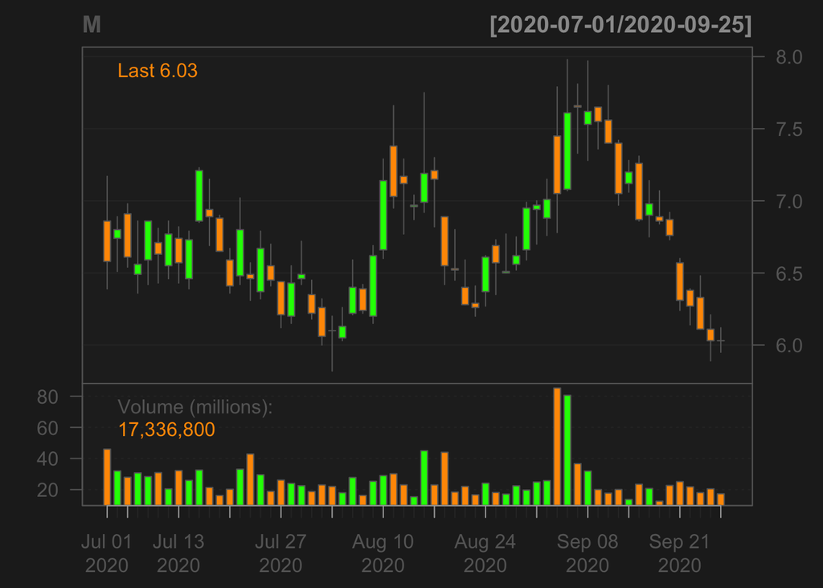

```r
# Macy's
options(repr.plot.width = 6, repr.plot.height = 3)
chartSeries(M, subset = "last 3 months")
```

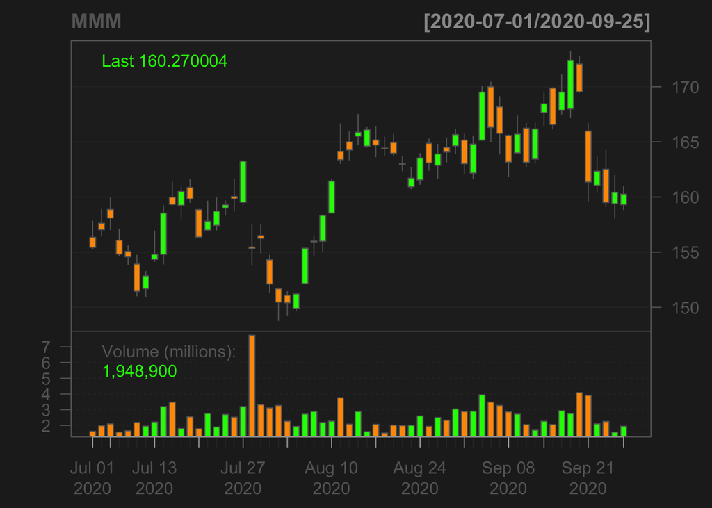

```r
# 3M
options(repr.plot.width = 6, repr.plot.height = 3)
chartSeries(MMM, subset = "last 3 months")
```

### First half of 2020

### Between Feb and March, inevitably all 3 stock plummeted in the 2020 stock market crash. But Netflix restored quickly and the stock price increased in the following months. The Stay-at-Home Orders prompted the increase of Netflix because streaming is one of the few entertainment options. Macy’s stock drop represents the struggle of most department stores in the pandemic. But there are already early signs of crisis in department stores with the rise of e-commerce.

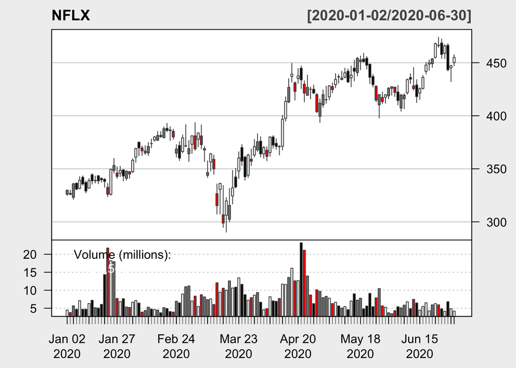

```r
options(repr.plot.width = 6, repr.plot.height = 3)
candleChart(NFLX,subset = "2020::2020-06",multi.col=TRUE, theme='white')
```

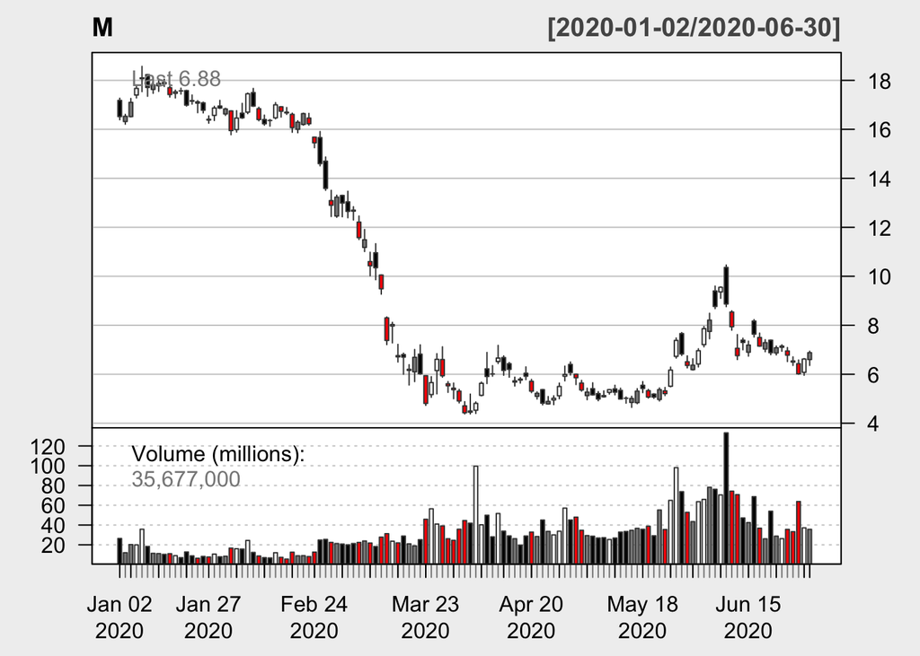

```r
options(repr.plot.width = 6, repr.plot.height = 3)
candleChart(M,subset = "2020::2020-06",multi.col=TRUE, theme='white')
```

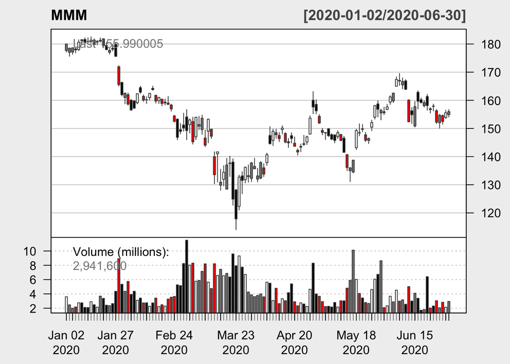

```r
options(repr.plot.width = 6, repr.plot.height = 3)
candleChart(MMM,subset = "2020::2020-06",multi.col=TRUE, theme='white')
```

### 2020 Jan. till now

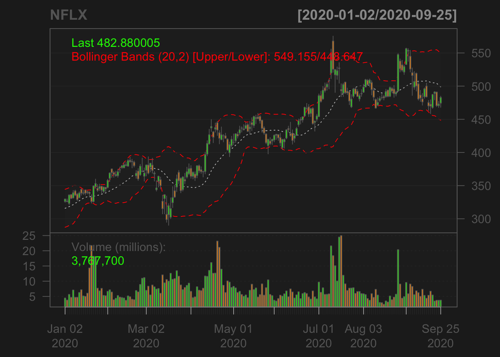

```r
options(repr.plot.width = 6, repr.plot.height = 3)
chartSeries(NFLX, subset = "2020::2020-09", TA = c(addVo(), addBBands()))  #add volume and Bollinger Bands from TTR
```

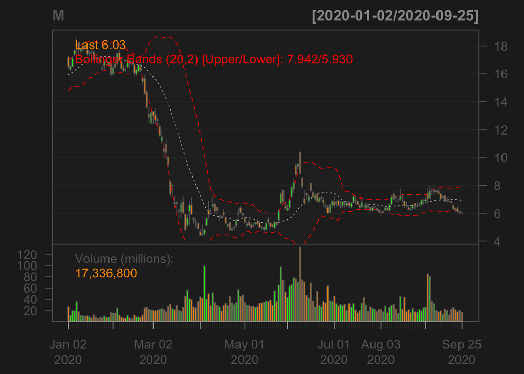

```r
options(repr.plot.width = 6, repr.plot.height = 3)
chartSeries(M, subset = "2020::2020-09", TA = c(addVo(), addBBands()))
```

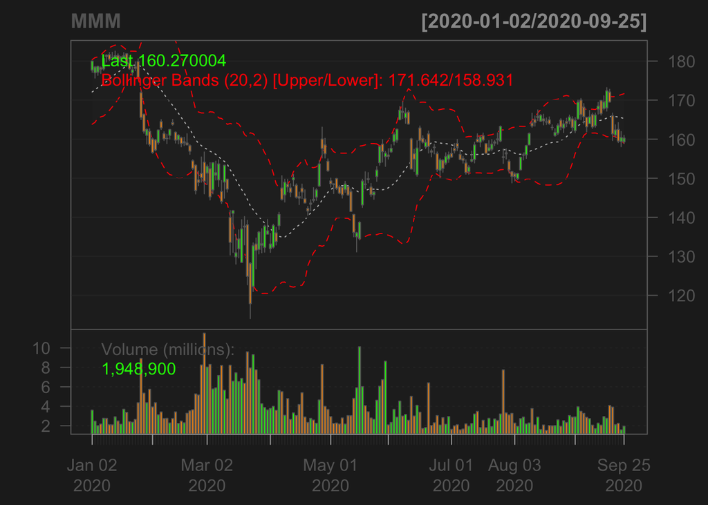

```r
options(repr.plot.width = 6, repr.plot.height = 3)
chartSeries(MMM, subset = "2020::2020-09", TA = c(addVo(), addBBands()))
```

### Next, I visualized the Long-term performance of these 3 stocks

### From the long-term perspective, we can see obvious differences among these stocks, which provide us a lens into the development of technology and changes in company prospects.

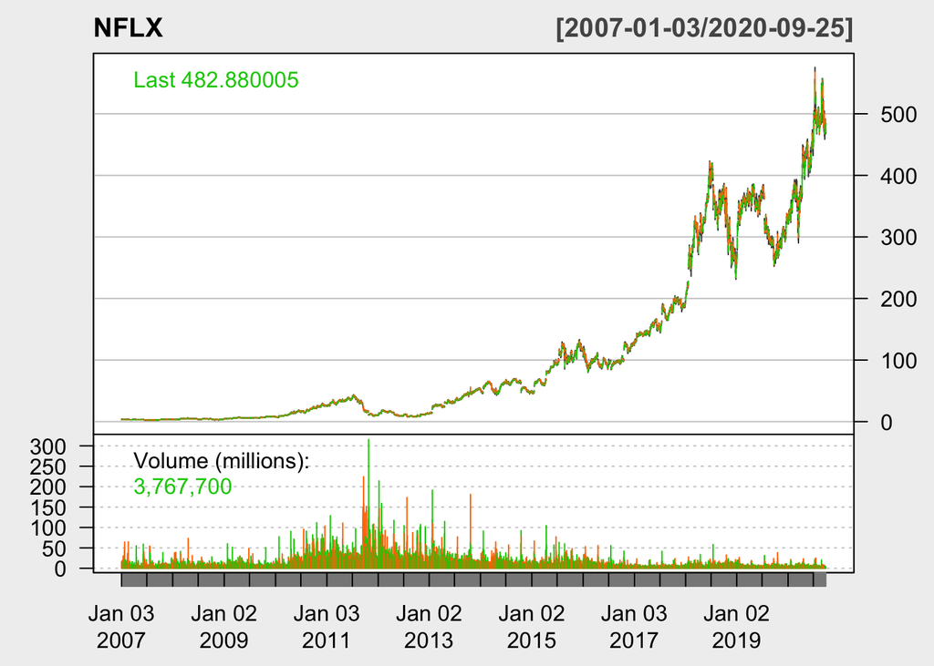

```r
options(repr.plot.width = 6, repr.plot.height = 3)
chartSeries(NFLX, theme = chartTheme("white"))
```

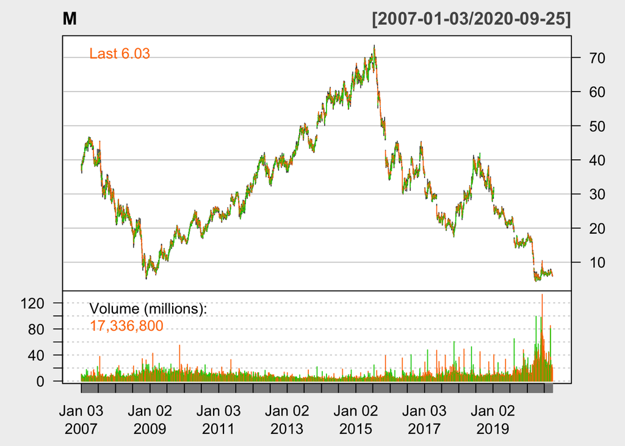

```r
options(repr.plot.width = 6, repr.plot.height = 3)
chartSeries(M, theme = chartTheme("white"))
```

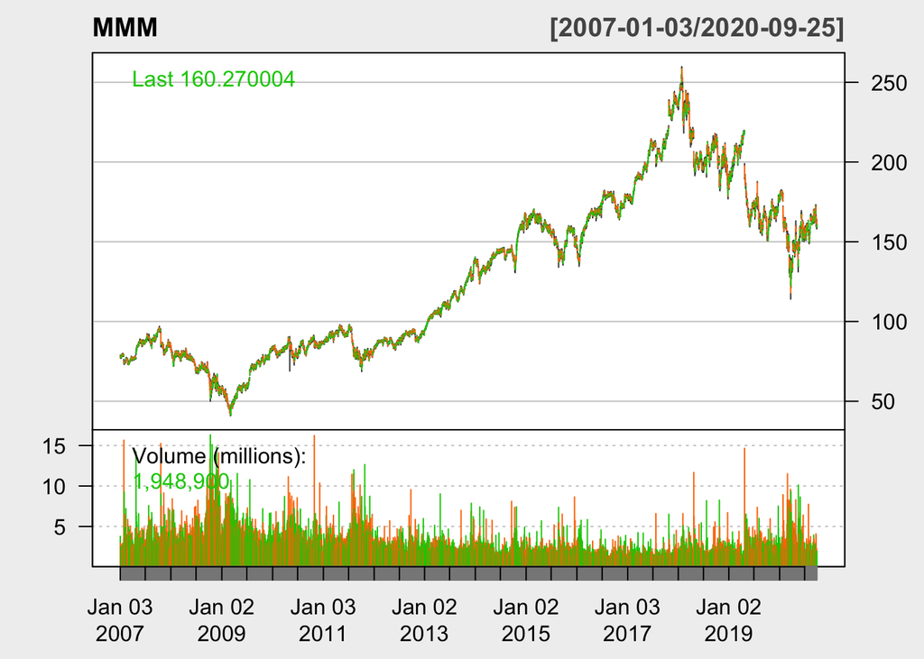

```r
options(repr.plot.width = 6, repr.plot.height = 3)
chartSeries(MMM, theme = chartTheme("white"))
```

### Last but not least, I visualized the stock price in the financial crisis of 2007-2008

### Again, Netflix stands out. We cannot even see this fluctuation in its’ above long-term plot.

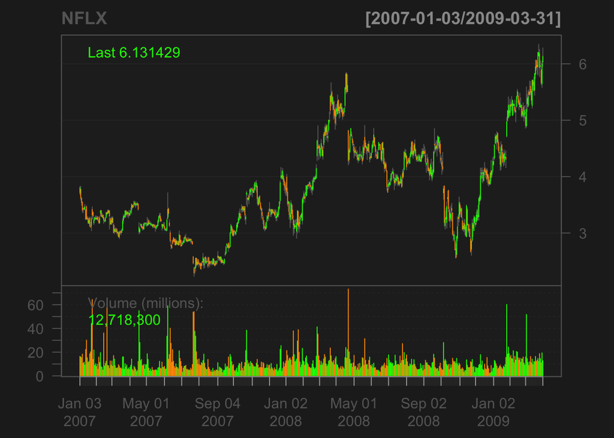

```r
options(repr.plot.width = 6, repr.plot.height = 3)
chartSeries(NFLX, subset = "2007::2009-03")
```

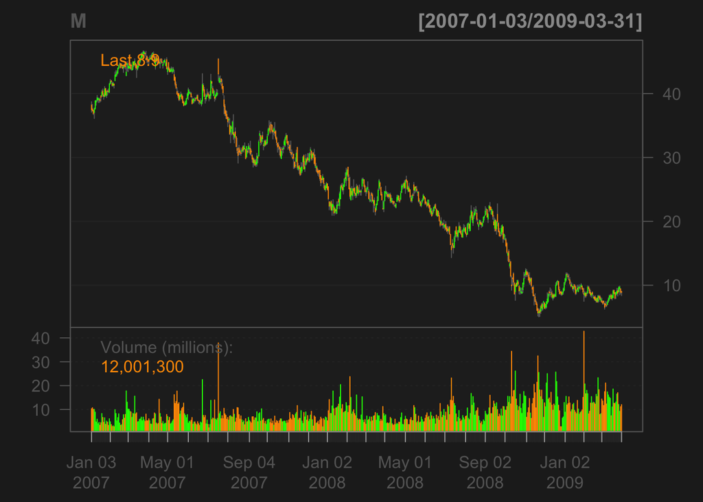

```r
options(repr.plot.width = 6, repr.plot.height = 3)
chartSeries(M, subset = "2007::2009-03")
```

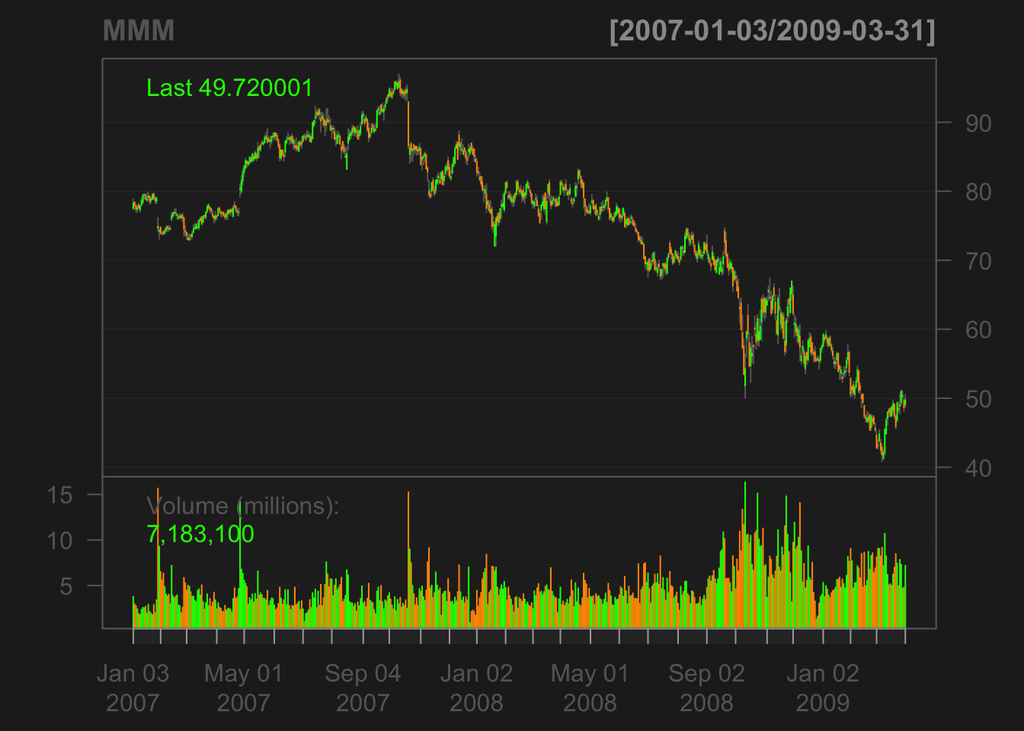

```r
options(repr.plot.width = 6, repr.plot.height = 3)
chartSeries(MMM, subset = "2007::2009-03")
```

### Conclusion: In the long-term, it is hard to beat the Buy and Hold strategy. But it is more important to choose a promising company to invest.